# Reproducible Research: Peer Assessment 1

## Loading and preprocessing the data

1. Load, unzip and read data

```r
#url<-"https://d396qusza40orc.cloudfront.net/repdata%2Fdata%2Factivity.zip"
#download.file(url, destfile="Factivity.zip")
#unzip("Factivity.zip", overwrite=TRUE)
data<-read.csv("activity.csv")
```

## What is mean total number of steps taken per day?

1. Filter data from “NA”. Then calculate the number of steps taken per day

```r
data_without_na<-na.omit(data)
library(plyr)
res_steps_sum<-ddply(data_without_na,.(Date=as.Date(data_without_na$date)),function(x) sum(x$steps))
```

2. Create histogram

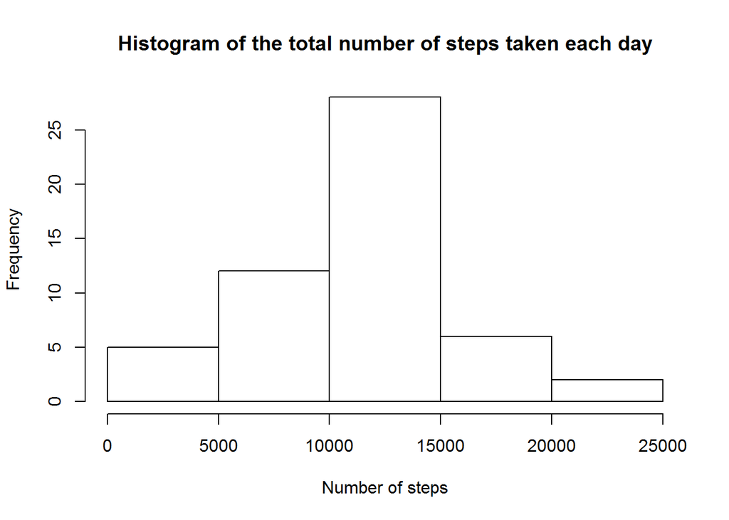

3. Calculate mean and median total number of steps taken per day.

```r
mean(res_steps_sum$V1)
```

```
## [1] 10766.19
```

```r
median(res_steps_sum$V1)
```

```
## [1] 10765
```

## What is the average daily activity pattern?

1. Calculate the average number of of steps

```r
res_interval_mean<-ddply(data_without_na,.(interval=data_without_na$interval),function(x) mean(x$steps))
```

Make a time series plot of the 5-minute interval

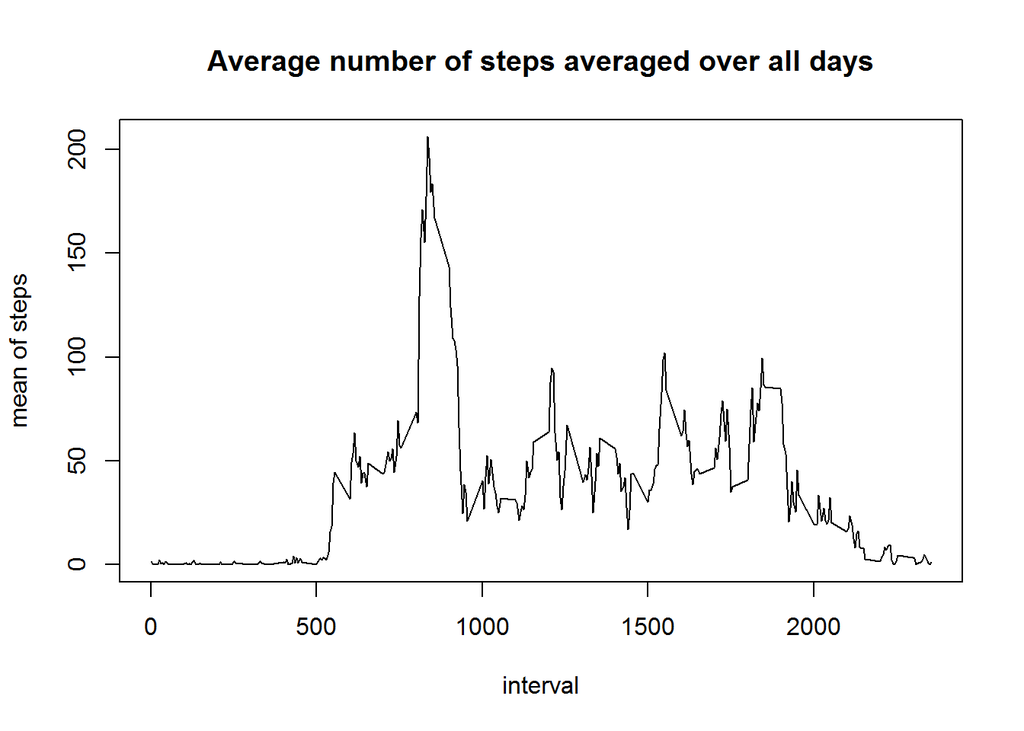

2. Calculate the 5-minute interval which contains the maximum number of steps

```r
res_interval_mean$interval[which.max(res_interval_mean$V1)]
```

```
## [1] 835
```

## Imputing missing values

1. Calculate and report the total number of missing values in the dataset

```r
count<-nrow(data)-nrow(data_without_na)
count
```

```
## [1] 2304
```

2. Devise a strategy for filling in all of the missing values in the dataset. Strategy in this case - data of “NA” equal to the minimum step

```r
data_na <- data[!complete.cases(data),]
for(i in 1:count){
    data_na$steps[i]=min(data_without_na$steps)
}
```

3. Create a new dataset that is equal to the original dataset but with the missing data filled in.

```r
data_new<-rbind(data_without_na, data_na)
```

4. Make a histogram of the total number of steps taken each day.

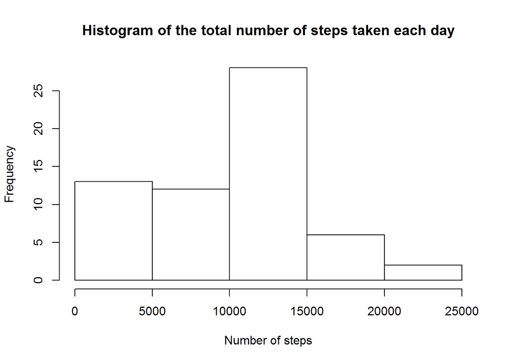

```r
res_steps_sum_all<-ddply(data_new,.(Date=as.Date(data_new$date)),function(x) sum(x$steps))
hist(res_steps_sum_all$V1, main="Histogram of the total number of steps taken each day", xlab="Number of steps")
```

Calculate and report the mean and median total number of steps taken per day.

```r
mean(res_steps_sum_all$V1)
```

```
## [1] 9354.23
```

```r
median(res_steps_sum_all$V1)
```

```
## [1] 10395
```

## Are there differences in activity patterns between weekdays and weekends?

1. Create a new factor variable in the dataset with two levels – “weekday” and “weekend” indicating whether a given date is a weekday or weekend day. Then combine data of weekend and weekday.

```r
Sys.setlocale("LC_TIME", "English")
```

```
## [1] "English_United States.1252"
```

```r
week<-weekdays(as.Date(data_without_na$date, "%Y-%m-%d"))

for(i in 1:length(week)){
    if((week[i]=="Saturday")|(week[i]=="Sunday"))
        week[i]="weekend" else week[i]="weekday"
}
data_without_na$week<-as.factor(week)

weekday<-data_without_na[data_without_na$week=="weekday", ]
weekend<-data_without_na[data_without_na$week=="weekend", ]

weekend_mean<-ddply(weekend,.(interval=weekend$interval),function(x) mean(x$steps))
week1="weekend"
weekend_mean$week<-as.factor(week1)

weekday_mean<-ddply(weekday,.(interval=weekday$interval),function(x) mean(x$steps))
week1="weekday"
weekday_mean$week<-as.factor(week1)

output<-rbind(weekday_mean, weekend_mean)
```

2. Make a panel plot containing a time series plot of the 5-minute interval (x-axis) and the average number of steps taken, averaged across all weekday days or weekend days (y-axis).

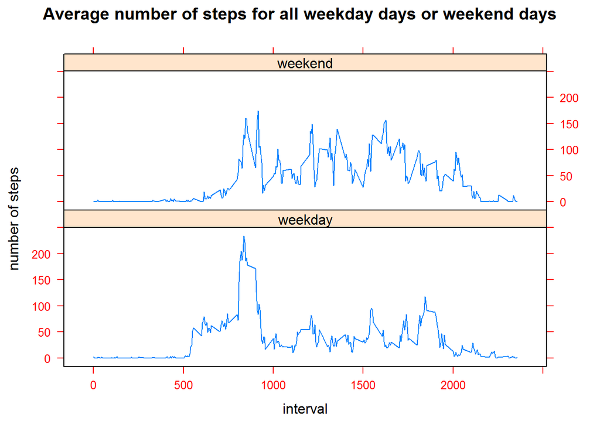

```r
library(lattice)
xyplot(V1 ~ interval | week, data = output,
       layout = c(1, 2), ylab = "number of steps",
       main = "Average number of steps for all weekday days or weekend days",
       scales=list(cex=.8, col="red"), type="l")
```